# GESTIÓN DEL RIESGO Y COBRANZA MEDIANTE MODELOS PREDICTIVOS EN CIENCIA DE DATOS EN EDUCACIÓN SUPERIOR

### 7.4 — Análisis costo-beneficio

El modelo solo justifica su existencia si el beneficio de la intervención supera el costo. Aquí parametrizo costos por zona y los enfrento contra la mora evitada.

```
ANALISIS COSTO-BENEFICIO (NIVEL ESTUDIANTE)
====================================================================================================

Poblacion: 3,650 estudiantes unicos en holdout temporal (2023-2024)
Exposicion total en mora real: $2,869,548,878

Costos unitarios POR ESTUDIANTE:
  Verde    (sin intervencion):              $       0 COP
  Amarillo (SMS / correo):                  $    500 COP
  Naranja  (llamada + SMS previo):          $  5,500 COP
  Rojo     (gestion presencial + llamada):  $ 30,000 COP

Efectividad por zona (Escenario BASE):
  Rojo (>=80%)            Conservador:   25%   Base:   35%   Optimista:   45%
  Naranja (60-80%)        Conservador:   15%   Base:   25%   Optimista:   35%
  Amarillo (30-60%)       Conservador:    5%   Base:   15%   Optimista:   25%
  Verde (<30%)            Conservador:    0%   Base:    0%   Optimista:   10%

TABLA PRINCIPAL (Escenario BASE: efectividad diferenciada por zona)
====================================================================================================
Zona                    N est.    Costo Total     Cartera Mora   Benef. Base   ROI Base  $/$1 Inv.
----------------------------------------------------------------------------------------------------
  Rojo (>=80%)             175 $   5,250,000 $ 1,574,948,521 $551,231,982    +10400%     $105.0
  Naranja (60-80%)         428 $   2,354,000 $   371,271,095 $ 92,817,774     +3843%      $39.4
  Amarillo (30-60%)      2,860 $   1,430,000 $   878,038,343 $131,705,751     +9110%      $92.1
  Verde (<30%)             187 $           0 $    45,290,919 $          0        N/A          —
----------------------------------------------------------------------------------------------------
  TOTAL                  3,650 $   9,034,000 $ 2,869,548,878 $775,755,508     +8487% $     85.9

ANALISIS DE SENSIBILIDAD (Efectividad +/-10pp por zona)
====================================================================================================
Escenario      Efectividad (Am / Nar / Rojo)       Beneficio total    ROI total
----------------------------------------------------------------------------------------------------
  Conservador  Am  5% / Nar 15% / Rojo 25%      $     493,329,712      +5361%
  Base         Am 15% / Nar 25% / Rojo 35%      $     775,755,508      +8487%
  Optimista    Am 25% / Nar 35% / Rojo 45%      $   1,062,710,395     +11663%

CONCLUSION:
  Bajo el escenario BASE (efectividad diferenciada por zona), por cada $1
  invertido en intervencion preventiva se mitigan ~$85.9 en cartera
  morosa esperada. ROI base = +8487%.
  Rango de sensibilidad: ROI total en [+5361%, +11663%].

  NOTA METODOLOGICA:
    El analisis se interpreta como SIMULACION DE MITIGACION ESPERADA,
    no recuperacion garantizada. La intervencion se modela a NIVEL DE
    ESTUDIANTE (no obligacion). La efectividad por zona refleja que
    la intensidad varia: SMS masivo (Amarillo, 15% base), llamada con
    plan de pagos (Naranja, 25%) y gestion presencial con codeudor
    (Rojo, 35%). Verde no recibe intervencion activa.
```

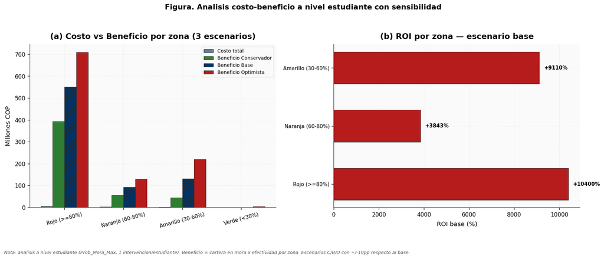

```python
# 7.4 - Analisis costo-beneficio a NIVEL ESTUDIANTE
# ============================================================================
# Cambio metodologico clave (Rev. 3):
#   1) Unidad de contacto: ESTUDIANTE, no obligacion. Un estudiante recibe
#      una sola gestion segun su zona de mayor riesgo.
#   2) Exposicion: SUMA de Valor_nota_debito de las obligaciones del estudiante
#      que efectivamente entraron en mora real (Cartera_En_Mora).
#   3) Beneficio: PARCIAL (efectividad diferenciada por zona) y con analisis
#      de sensibilidad (escenarios Conservador / Base / Optimista, +/-10pp).
#
# Costo unitario por estudiante segun zona:
#   - Amarillo (30-60%): SMS / correo = 500 COP
#   - Naranja (60-80%):  llamada del asesor + SMS previo = 5,500 COP
#   - Rojo (>=80%):      gestion presencial + llamada previa = 30,000 COP
#
# Efectividad (escenario BASE) diferenciada por intensidad de intervencion:
#   - Amarillo: 15% (SMS masivo, baja conversion)
#   - Naranja:  25% (contacto telefonico personalizado)
#   - Rojo:     35% (gestion presencial con codeudor)
# Sensibilidad +/-10pp: Conservador (5%/15%/25%), Optimista (25%/35%/45%).

COSTO_SMS      = 500
COSTO_LLAMADA  = 5_000
COSTO_VISITA   = 25_000

ZONAS_ORDEN = ['Rojo (>=80%)', 'Naranja (60-80%)', 'Amarillo (30-60%)', 'Verde (<30%)']

EFECTIVIDAD_BASE = {
    'Verde (<30%)'     : 0.00,
    'Amarillo (30-60%)': 0.15,
    'Naranja (60-80%)' : 0.25,
    'Rojo (>=80%)'     : 0.35,
}
EFECTIVIDAD_CONS = {k: max(0.0, v - 0.10) for k, v in EFECTIVIDAD_BASE.items()}
EFECTIVIDAD_OPT  = {k: v + 0.10 for k, v in EFECTIVIDAD_BASE.items()}

COSTO_ZONA = {
    'Verde (<30%)'     : 0,
    'Amarillo (30-60%)': COSTO_SMS,
    'Naranja (60-80%)' : COSTO_LLAMADA + COSTO_SMS,
    'Rojo (>=80%)'     : COSTO_VISITA + COSTO_LLAMADA,
}

def asignar_zona(p):
    if p >= 0.80: return 'Rojo (>=80%)'
    elif p >= 0.60: return 'Naranja (60-80%)'
    elif p >= 0.30: return 'Amarillo (30-60%)'
    else: return 'Verde (<30%)'

df_sim_est['Zona']                = df_sim_est['Prob_Mora_Max'].apply(asignar_zona)
df_sim_est['Costo_Intervencion']  = df_sim_est['Zona'].map(COSTO_ZONA)
df_sim_est['Efect_Base']          = df_sim_est['Zona'].map(EFECTIVIDAD_BASE)
df_sim_est['Beneficio_Base']      = df_sim_est['Cartera_En_Mora'] * df_sim_est['Efect_Base']

print("ANALISIS COSTO-BENEFICIO (NIVEL ESTUDIANTE)")
print("=" * 100)
print(f"\nPoblacion: {n_estudiantes:,} estudiantes unicos en holdout temporal (2023-2024)")
print(f"Exposicion total en mora real: ${cartera_mora_total:,.0f}")
print(f"\nCostos unitarios POR ESTUDIANTE:")
print(f"  Verde    (sin intervencion):              $       0 COP")
print(f"  Amarillo (SMS / correo):                  ${COSTO_SMS:>7,} COP")
print(f"  Naranja  (llamada + SMS previo):          ${COSTO_LLAMADA + COSTO_SMS:>7,} COP")
print(f"  Rojo     (gestion presencial + llamada):  ${COSTO_VISITA + COSTO_LLAMADA:>7,} COP")

print(f"\nEfectividad por zona (Escenario BASE):")
for z in ZONAS_ORDEN:
    print(f"  {z:<22}  Conservador: {EFECTIVIDAD_CONS[z]*100:>4.0f}%   "
          f"Base: {EFECTIVIDAD_BASE[z]*100:>4.0f}%   "
          f"Optimista: {EFECTIVIDAD_OPT[z]*100:>4.0f}%")

print()
print("TABLA PRINCIPAL (Escenario BASE: efectividad diferenciada por zona)")
print("=" * 100)
print(f"{'Zona':<22} {'N est.':>7} {'Costo Total':>14} {'Cartera Mora':>16} "
      f"{'Benef. Base':>13} {'ROI Base':>10} {'$/$1 Inv.':>10}")
print("-" * 100)

resumen_zonas = []
for zona in ZONAS_ORDEN:
    df_z = df_sim_est[df_sim_est['Zona'] == zona]
    n_z = len(df_z)
    if n_z == 0:
        continue
    costo_z       = df_z['Costo_Intervencion'].sum()
    cartera_z     = df_z['Cartera_En_Mora'].sum()
    mora_real_pct = (df_z['Obligaciones_mora'] > 0).mean() * 100
    benef_cons    = cartera_z * EFECTIVIDAD_CONS[zona]
    benef_base    = cartera_z * EFECTIVIDAD_BASE[zona]
    benef_opt     = cartera_z * EFECTIVIDAD_OPT[zona]
    roi_base      = ((benef_base - costo_z) / max(costo_z, 1)) * 100 if costo_z > 0 else float('nan')
    roi_cons      = ((benef_cons - costo_z) / max(costo_z, 1)) * 100 if costo_z > 0 else float('nan')
    roi_opt       = ((benef_opt  - costo_z) / max(costo_z, 1)) * 100 if costo_z > 0 else float('nan')
    ratio_base    = benef_base / max(costo_z, 1) if costo_z > 0 else float('nan')
    resumen_zonas.append({
        'Zona': zona, 'N_est': n_z, 'Mora_real_pct': mora_real_pct,
        'Costo': costo_z, 'Cartera_Mora': cartera_z,
        'Benef_Cons': benef_cons, 'Benef_Base': benef_base, 'Benef_Opt': benef_opt,
        'ROI_Cons': roi_cons, 'ROI_Base': roi_base, 'ROI_Opt': roi_opt,
        'Ratio_Base': ratio_base,
    })
    roi_str = f"{roi_base:+.0f}%" if not pd.isna(roi_base) else "N/A"
    ratio_str = f"${ratio_base:.1f}" if not pd.isna(ratio_base) else "—"
    print(f"  {zona:<22} {n_z:>5,} ${costo_z:>12,.0f} ${cartera_z:>14,.0f} "
          f"${benef_base:>11,.0f} {roi_str:>10} {ratio_str:>10}")

df_cb_est = pd.DataFrame(resumen_zonas)
total_costo  = df_cb_est['Costo'].sum()
total_b_base = df_cb_est['Benef_Base'].sum()
total_b_cons = df_cb_est['Benef_Cons'].sum()
total_b_opt  = df_cb_est['Benef_Opt'].sum()
roi_t_base = ((total_b_base - total_costo) / max(total_costo, 1)) * 100
roi_t_cons = ((total_b_cons - total_costo) / max(total_costo, 1)) * 100
roi_t_opt  = ((total_b_opt  - total_costo) / max(total_costo, 1)) * 100
ratio_total_base = total_b_base / max(total_costo, 1)

print("-" * 100)
print(f"  {'TOTAL':<22} {n_estudiantes:>5,} ${total_costo:>12,.0f} ${cartera_mora_total:>14,.0f} "
      f"${total_b_base:>11,.0f} {roi_t_base:>+9.0f}% ${ratio_total_base:>9.1f}")

print()
print("ANALISIS DE SENSIBILIDAD (Efectividad +/-10pp por zona)")
print("=" * 100)
print(f"{'Escenario':<14} {'Efectividad (Am / Nar / Rojo)':<32} "
      f"{'Beneficio total':>18} {'ROI total':>12}")
print("-" * 100)
print(f"  {'Conservador':<12} "
      f"{'Am  5% / Nar 15% / Rojo 25%':<32} "
      f"${total_b_cons:>16,.0f} {roi_t_cons:>+10.0f}%")
print(f"  {'Base':<12} "
      f"{'Am 15% / Nar 25% / Rojo 35%':<32} "
      f"${total_b_base:>16,.0f} {roi_t_base:>+10.0f}%")
print(f"  {'Optimista':<12} "
      f"{'Am 25% / Nar 35% / Rojo 45%':<32} "
      f"${total_b_opt:>16,.0f} {roi_t_opt:>+10.0f}%")

print()
print("CONCLUSION:")
print(f"  Bajo el escenario BASE (efectividad diferenciada por zona), por cada $1")
print(f"  invertido en intervencion preventiva se mitigan ~${ratio_total_base:.1f} en cartera")
print(f"  morosa esperada. ROI base = +{roi_t_base:.0f}%.")
print(f"  Rango de sensibilidad: ROI total en [+{roi_t_cons:.0f}%, +{roi_t_opt:.0f}%].")
print()
print("  NOTA METODOLOGICA:")
print("    El analisis se interpreta como SIMULACION DE MITIGACION ESPERADA,")
print("    no recuperacion garantizada. La intervencion se modela a NIVEL DE")
print("    ESTUDIANTE (no obligacion). La efectividad por zona refleja que")
print("    la intensidad varia: SMS masivo (Amarillo, 15% base), llamada con")
print("    plan de pagos (Naranja, 25%) y gestion presencial con codeudor")
print("    (Rojo, 35%). Verde no recibe intervencion activa.")

# Figura: barras agrupadas costo vs beneficio por escenario, ROI por zona
fig, axes = plt.subplots(1, 2, figsize=(15, 6))

# Panel A: barras agrupadas por zona (costo vs beneficios 3 escenarios)
zonas_plot = [z for z in ZONAS_ORDEN if z in df_cb_est['Zona'].values]
x = np.arange(len(zonas_plot))
w = 0.20
for k, (lbl, key, col, hatch) in enumerate([
        ('Costo total', 'Costo', GRIS_MEDIO, ''),
        ('Beneficio Conservador', 'Benef_Cons', COLOR_BAJO, ''),
        ('Beneficio Base', 'Benef_Base', AZUL_UAO, '///'),
        ('Beneficio Optimista', 'Benef_Opt', COLOR_ALTO, ''),
    ]):
    vals = [df_cb_est[df_cb_est['Zona']==z][key].values[0]/1e6 for z in zonas_plot]
    axes[0].bar(x + (k-1.5)*w, vals, w, label=lbl, color=col,
                edgecolor='#2B2B2B', linewidth=0.6, hatch=hatch, zorder=3)
axes[0].set_xticks(x)
axes[0].set_xticklabels(zonas_plot, rotation=15, fontsize=9)
axes[0].set_ylabel('Millones COP')
axes[0].set_title('(a) Costo vs Beneficio por zona (3 escenarios)',
                  fontweight='bold')
axes[0].legend(fontsize=8.5)
axes[0].yaxis.grid(True, linestyle=':', alpha=0.35)

# Panel B: ROI base por zona (horizontal bars)
zonas_roi = df_cb_est.dropna(subset=['ROI_Base'])
y = np.arange(len(zonas_roi))
colores_roi = [COLOR_ALTO if r >= 500 else (COLOR_MEDIO if r >= 100 else COLOR_BAJO)
               for r in zonas_roi['ROI_Base']]
axes[1].barh(y, zonas_roi['ROI_Base'], color=colores_roi,
             edgecolor='#2B2B2B', linewidth=0.6, height=0.55, zorder=3)
axes[1].axvline(0, color=GRIS_MEDIO, ls='-', lw=1.0, alpha=0.7)
axes[1].set_yticks(y)
axes[1].set_yticklabels(zonas_roi['Zona'], fontsize=9)
axes[1].set_xlabel('ROI base (%)')
axes[1].set_title('(b) ROI por zona — escenario base', fontweight='bold')
axes[1].xaxis.grid(True, linestyle=':', alpha=0.35)
for yi, ri in zip(y, zonas_roi['ROI_Base']):
    axes[1].text(ri + (max(zonas_roi['ROI_Base'])*0.02), yi,
                 f'{ri:+.0f}%', va='center', fontsize=9, fontweight='bold')

fig.suptitle('Figura. Analisis costo-beneficio a nivel estudiante con sensibilidad',
             fontsize=13, fontweight='bold')
plt.tight_layout(rect=[0, 0.03, 1, 0.95])
guardar(fig, 'fig_costo_beneficio.png',
        'Nota: analisis a nivel estudiante (Prob_Mora_Max, 1 intervencion/estudiante). '
        'Beneficio = cartera en mora x efectividad por zona. Escenarios C/B/O '
        'con +/-10pp respecto al base.')
```

```python
# 7.2 - EXPORTAR RESULTADOS PARA DASHBOARD (Power BI / Excel)
# Exportar predicciones completas
df_export = df_pred.copy()
df_export.to_csv('predicciones_UAO_riesgo_crediticio.csv', index=False)

# Exportar perfiles de clusters
perfil.to_csv('perfiles_clusters_UAO.csv')

# Exportar resumen por zona
zona_resumen.to_csv('zonas_riesgo_UAO.csv')

print("Archivos exportados:")
print("   → predicciones_UAO_riesgo_crediticio.csv")
print("   → perfiles_clusters_UAO.csv")
print("   → zonas_riesgo_UAO.csv")
print("\n   Estos archivos pueden importarse directamente en Power BI")
print("   para construir el tablero de control interactivo.")
```

```
Archivos exportados:
   → predicciones_UAO_riesgo_crediticio.csv
   → perfiles_clusters_UAO.csv
   → zonas_riesgo_UAO.csv

   Estos archivos pueden importarse directamente en Power BI
   para construir el tablero de control interactivo.
```

## FASE 7.5 — Tablero de control interactivo (Plotly)

El tablero materializa el resultado esperado del proyecto:

> *"Diseño de un tablero de control interactivo que integre visualización de resultados predictivos y segmentación de perfiles de riesgo, orientado a apoyar decisiones estratégicas en la gestión del crédito educativo."*

```python
# TABLERO DE CONTROL INTERACTIVO - Plotly Dashboard
import plotly.graph_objects as go
from plotly.subplots import make_subplots

# Datos de entrada
zona_counts = df_pred['Zona_Riesgo'].value_counts().reindex(labels_cobranza).fillna(0)

fig_dash = make_subplots(
    rows=3, cols=2,
    subplot_titles=[
        'Distribución por Zona de Riesgo',
        'Score Promedio por Cluster',
        'Curva de Ganancia Acumulada',
        'Top Variables Predictoras',
        'Indicadores Clave del Modelo',
        'Composición de la Cartera por Nivel de Formación'
    ],
    specs=[
        [{'type': 'bar'},    {'type': 'bar'}],
        [{'type': 'scatter'}, {'type': 'bar'}],
        [{'type': 'table'},  {'type': 'pie'}]
    ],
    vertical_spacing=0.08
)

# Panel 1: Zonas de riesgo
_zona_colors = ['#27AE60', '#F39C12', '#E67E22', '#E74C3C']
fig_dash.add_trace(
    go.Bar(x=labels_cobranza, y=zona_counts.values,
           marker_color=_zona_colors, marker_line_color='black', marker_line_width=1,
           text=[f'{int(v):,}' for v in zona_counts.values],
           textposition='outside', name='Estudiantes', showlegend=False),
    row=1, col=1)

# Panel 2: Score por cluster
_cl_labels = [f'Cluster {int(c)}' for c in perfil.index]
_cl_colors = ['#27AE60', '#E74C3C', '#9B59B6', '#3498DB'][:len(perfil)]
fig_dash.add_trace(
    go.Bar(x=_cl_labels, y=(perfil['Score_Mora_Medio']*100).tolist(),
           marker_color=_cl_colors, marker_line_color='black', marker_line_width=1,
           text=[f"{v:.1f}%" for v in (perfil['Score_Mora_Medio']*100).tolist()],
           textposition='outside', name='Score', showlegend=False),
    row=1, col=2)

# Panel 3: Curva de ganancia
fig_dash.add_trace(
    go.Scatter(x=pct_poblacion.tolist(), y=pct_morosos_acum.tolist(),
               mode='lines', line=dict(color='#E74C3C', width=2.5),
               name=mejor_modelo, fill='tozeroy', fillcolor='rgba(231,76,60,0.10)'),
    row=2, col=1)
fig_dash.add_trace(
    go.Scatter(x=[0,100], y=[0,100], mode='lines',
               line=dict(color='gray', dash='dash', width=1),
               name='Aleatorio', showlegend=False),
    row=2, col=1)

# Panel 4: Top variables
_top5 = df_imp.sort_values('Importancia', ascending=False).head(7)
fig_dash.add_trace(
    go.Bar(x=_top5['Importancia'].tolist(), y=_top5['Variable'].tolist(),
           orientation='h', marker_color=['#E74C3C']*3 + ['#003366']*4,
           marker_line_color='black', marker_line_width=0.8,
           text=[f'{v:.3f}' for v in _top5['Importancia'].tolist()],
           textposition='outside', name='Importancia', showlegend=False),
    row=2, col=2)

# Panel 5: KPIs del modelo
auc_val = resultados[mejor_modelo]['auc_roc']
rec_val = resultados[mejor_modelo]['recall']
f1_val = resultados[mejor_modelo]['f1']
prec_val = resultados[mejor_modelo]['precision']

fig_dash.add_trace(
    go.Table(
        header=dict(values=['Indicador', 'Valor'],
                    fill_color='#003366', font=dict(color='white', size=12),
                    align='left'),
        cells=dict(values=[
            ['Modelo seleccionado', 'AUC-ROC (Holdout)', 'Recall', 'Precisión',
             'F1-Score', 'Degradación CV-Holdout', 'Registros modelados',
             'Tasa de mora base', 'ROI estrategia cobranza'],
            [mejor_modelo, f'{auc_val:.4f}', f'{rec_val:.4f}', f'{prec_val:.4f}',
             f'{f1_val:.4f}', f'{resultados_cv[mejor_modelo]["roc_auc"]["mean"] - auc_val:.4f}',
             f'{len(df_modelo):,}', f'{df_modelo["En_Mora"].mean()*100:.1f}%',
             f'+{roi_t_base:.0f}%']
        ], fill_color=[['#F0F0F0', 'white']*5], align='left', font=dict(size=11))
    ), row=3, col=1)

# Panel 6: Composición por nivel
if 'Nivel_Formacion' in df1.columns:
    nf_counts = df1['Nivel_Formacion'].value_counts()
    fig_dash.add_trace(
        go.Pie(labels=nf_counts.index.tolist(), values=nf_counts.values.tolist(),
               marker=dict(colors=['#4E79A7', '#F28E2B', '#59A14F', '#E15759', '#76B7B2', '#EDC948']),
               textinfo='label+percent', hole=0.3, showlegend=False),
        row=3, col=2)

fig_dash.update_layout(
    title=dict(
        text=f'<b>Tablero de Control - Gestión del Riesgo Crediticio UAO</b><br>'
             f'<span style="font-size:12px">Modelo: {mejor_modelo} | AUC: {auc_val:.3f} | '
             f'Datos: 2015-2024 | {len(df_modelo):,} créditos analizados</span>',
        font=dict(size=16)),
    height=1100, width=1200,
    template='plotly_white',
    font=dict(family='Arial', size=11)
)
fig_dash.update_xaxes(title_text='% Población intervenida', row=2, col=1)
fig_dash.update_yaxes(title_text='% Morosos capturados', row=2, col=1)

fig_dash.write_html('tablero_control_UAO_riesgo_crediticio.html')
fig_dash.show()
print("Tablero interactivo guardado: tablero_control_UAO_riesgo_crediticio.html")
```

[output not shown]

```
Tablero interactivo guardado: tablero_control_UAO_riesgo_crediticio.html
```

## FASE 7.6 — Paquete de entregables

Exportación de los artefactos para reproducir y presentar el proyecto:

| Archivo | Contenido |
| --- | --- |
| `entregables_UAO_riesgo.xlsx` | Tablas clave en un único Excel |
| `tablero_control_UAO_riesgo_crediticio.html` | Dashboard interactivo Plotly |
| `graficos_tesis/` | Todas las figuras del análisis |

```python
# FASE 7.6 - PAQUETE DE ENTREGABLES
import openpyxl
EXCEL_OUT = RUTA_DATOS / 'entregables_UAO_riesgo.xlsx'

with pd.ExcelWriter(EXCEL_OUT, engine='openpyxl') as writer:

    # ── Hoja 1: Diccionario de variables ──
    dict_vars = pd.DataFrame([
        {'Variable':'Estrato_num',           'Tipo':'Numérica','Fuente':'df1','Descripción':'Estrato socioeconómico (1-6)'},
        {'Variable':'Es_Femenino',           'Tipo':'Binaria', 'Fuente':'df1','Descripción':'1=Femenino, 0=Masculino'},
        {'Variable':'Es_Primiparo',          'Tipo':'Binaria', 'Fuente':'df1','Descripción':'1=Estudiante nuevo'},
        {'Variable':'Es_Activo',             'Tipo':'Binaria', 'Fuente':'df1','Descripción':'1=Estado académico Activo'},
        {'Variable':'N_Creditos_Previos',    'Tipo':'Numérica','Fuente':'Derivada','Descripción':'Conteo real de créditos anteriores del estudiante'},
        {'Variable':'Cuotas',                'Tipo':'Numérica','Fuente':'df1','Descripción':'Número de cuotas pactadas'},
        {'Variable':'Valor_nota_debito',     'Tipo':'Numérica','Fuente':'df1','Descripción':'Monto del crédito otorgado (COP)'},
        {'Variable':'Valor_financiacion',    'Tipo':'Numérica','Fuente':'df1','Descripción':'Valor total financiado (COP)'},
        {'Variable':'Anio',                  'Tipo':'Numérica','Fuente':'df1','Descripción':'Año académico'},
        {'Variable':'Semestre',              'Tipo':'Numérica','Fuente':'df1','Descripción':'Semestre (1 o 2)'},
        {'Variable':'Mora_Semestre_Anterior','Tipo':'Binaria', 'Fuente':'df1','Descripción':'1=Tuvo mora en semestre t-1 (feature histórica)'},
        {'Variable':'N_Moras_Hist',          'Tipo':'Numérica','Fuente':'df1','Descripción':'N° semestres con mora en historial del estudiante'},
        {'Variable':'Pct_Mora_Hist',         'Tipo':'Numérica','Fuente':'df1','Descripción':'Tasa histórica de mora del estudiante (0-1)'},
        {'Variable':'En_Mora',               'Tipo':'Target',  'Fuente':'df1','Descripción':'1=Crédito entró en CARTERA (incumplimiento)'},
    ])
    dict_vars.to_excel(writer, sheet_name='1_Diccionario_Variables', index=False)

    # ── Hoja 2: Estadísticas descriptivas ──
    try:
        _cols_desc = [c for c in FEATURES + ['En_Mora'] if c in df_modelo.columns]
        desc_out = df_modelo[_cols_desc].describe(percentiles=[.05,.25,.50,.75,.95]).T
        desc_out['CV%'] = (desc_out['std'] / desc_out['mean'].replace(0, np.nan) * 100).round(1)
        desc_out.to_excel(writer, sheet_name='2_Estadisticas_Descriptivas')
    except Exception as e:
        pd.DataFrame({'error':[str(e)]}).to_excel(writer, sheet_name='2_Estadisticas_Descriptivas')

    # ── Hoja 3: Métricas por modelo ──
    try:
        df_metricas.to_excel(writer, sheet_name='3_Metricas_Modelos')
    except Exception as e:
        pd.DataFrame({'error':[str(e)]}).to_excel(writer, sheet_name='3_Metricas_Modelos')

    # ── Hoja 4: Importancia de variables ──
    try:
        df_imp.sort_values('Importancia', ascending=False).to_excel(
            writer, sheet_name='4_Importancia_Variables', index=False)
    except Exception as e:
        pd.DataFrame({'error':[str(e)]}).to_excel(writer, sheet_name='4_Importancia_Variables')

    # ── Hoja 5: Perfiles de clusters ──
    try:
        perfil.to_excel(writer, sheet_name='5_Perfiles_Clusters')
    except Exception as e:
        pd.DataFrame({'error':[str(e)]}).to_excel(writer, sheet_name='5_Perfiles_Clusters')

    # ── Hoja 6: Tabla de deciles ──
    try:
        tabla_deciles.to_excel(writer, sheet_name='6_Tabla_Deciles')
    except Exception as e:
        pd.DataFrame({'error':[str(e)]}).to_excel(writer, sheet_name='6_Tabla_Deciles')

    # ── Hoja 7: Validación target df2 ──
    try:
        if 'cruce' in dir() and len(cruce) > 0:
            ec_table = cruce['Edad_Cartera'].value_counts().sort_index().reset_index()
            ec_table.columns = ['Edad_Cartera', 'N_Creditos']
            ec_table.to_excel(writer, sheet_name='7_Validacion_Target_df2', index=False)
    except Exception as e:
        pd.DataFrame({'error':[str(e)]}).to_excel(writer, sheet_name='7_Validacion_Target_df2')

    # ── Hoja 8: Análisis costo-beneficio ──
    try:
        # Construir export desde df_cb_est (analisis a nivel estudiante, Rev.3)
        df_cb_res = pd.DataFrame({
            'Zona':      df_cb_est['Zona'],
            'N':         df_cb_est['N_est'],
            'Costo':     df_cb_est['Costo'],
            'Beneficio': df_cb_est['Benef_Base'],
            'ROI':       df_cb_est['ROI_Base'].fillna(0).round(0).astype(int),
            'Mora_Pct':  df_cb_est['Mora_real_pct'].round(0).astype(int),
        })
        df_cb_res.to_excel(writer, sheet_name='8_Costo_Beneficio', index=False)
    except Exception as e:
        pd.DataFrame({'error':[str(e)]}).to_excel(writer, sheet_name='8_Costo_Beneficio')

print(f'Entregables exportados a: {EXCEL_OUT}')
print(f'   Hojas incluidas:')
import openpyxl
wb = openpyxl.load_workbook(EXCEL_OUT)
for sh in wb.sheetnames:
    print(f'     → {sh}')
print(f'\n Tablero HTML: tablero_control_UAO_riesgo_crediticio.html')
print(f' Figuras:       {GRAFICOS.resolve()}')
print(f' Predicciones:  predicciones_UAO_riesgo_crediticio.csv')
```

```
Entregables exportados a: c:\Users\Asus\Documents\Tesis5CL\entregables_UAO_riesgo.xlsx
   Hojas incluidas:
     → 1_Diccionario_Variables
     → 2_Estadisticas_Descriptivas
     → 3_Metricas_Modelos
     → 4_Importancia_Variables
     → 5_Perfiles_Clusters
     → 6_Tabla_Deciles
     → 7_Validacion_Target_df2
     → 8_Costo_Beneficio

 Tablero HTML: tablero_control_UAO_riesgo_crediticio.html
 Figuras:       C:\Users\Asus\Documents\Tesis5CL\graficos_tesis
 Predicciones:  predicciones_UAO_riesgo_crediticio.csv
```

## FASE 7.7 — Scoring de la población objetivo 2025

Cierre del ciclo CRISP-DM: el modelo seleccionado se aplica sobre los créditos del año 2025 que fueron reservados en la sección 2.4.1 por inmadurez de cartera. El resultado es un archivo CSV con la zona de riesgo asignada a cada obligación (ALTO / MEDIO / BAJO), listo para ser entregado al Departamento de Apoyo Financiero como insumo para la priorización de cobranza preventiva del próximo semestre.

| Zona | Probabilidad de mora | Acción recomendada |
| --- | --- | --- |
| ALTO | ≥ 0.60 | Gestión intensiva (llamada + plan de pagos / contacto presencial) |
| MEDIO | 0.30 – 0.60 | Intervención preventiva (SMS, correo electrónico) |
| BAJO | < 0.30 | Monitoreo pasivo, sin intervención activa |

```python
# ================================================================
# Scoring de la población objetivo 2025
# ================================================================
# Cierra el ciclo CRISP-DM: aplica el modelo seleccionado a los créditos
# del año 2025 reservados en 2.4.1 por inmadurez de cartera. Exporta un
# CSV con Nota_debito, Cliente, Prob_Mora y Zona_Riesgo para alimentar la
# gestión preventiva de cobranza del próximo semestre.

# --- 1) Modelo a usar (preferencia por el modelo operativo identificado en 6.2.1) ---
try:
    nombre_modelo = modelo_operativo
except NameError:
    nombre_modelo = mejor_modelo
modelo_scoring = resultados[nombre_modelo]['modelo']

# --- 2) Población a scorear ---
# Caso normal: usar la partición 2025 reservada en el notebook.
# Caso de respaldo: si la partición no existe (notebook ejecutado parcialmente),
# se usa el holdout 2023-2024 como proxy y se documenta en la salida.
USAR_2025 = ('df_2025_reserva' in globals()
             and isinstance(df_2025_reserva, pd.DataFrame)
             and len(df_2025_reserva) > 0)

if USAR_2025:
    df_input = df_2025_reserva.copy()
    print(f"Modelo: {nombre_modelo}")
    print(f"Población objetivo: créditos 2025 reservados ({len(df_input):,} registros)")
else:
    df_input = X_test.reset_index(drop=True).copy()
    df_input['Cliente'] = range(len(df_input))
    df_input['Nota_debito'] = range(len(df_input))
    print(f"Modelo: {nombre_modelo}")
    print(f"Población objetivo: PROXY holdout 2023-2024 ({len(df_input):,} registros)")

# --- 3) Ingeniería de features (solo si la entrada es df_2025_reserva crudo) ---
# df_2025_reserva conserva las columnas originales de df1; se replica la misma
# transformación que se aplicó al dataset de modelado para que el vector de
# entrada quede idéntico al usado en el entrenamiento.
if USAR_2025:
    # 3.1 Binarias y categóricas → numéricas
    if 'Sexo' in df_input.columns:
        df_input['Es_Femenino'] = (df_input['Sexo'] == 'Femenino').astype(int)
    if 'Primiparo' in df_input.columns:
        df_input['Es_Primiparo'] = (df_input['Primiparo'] == 'SI').astype(int)
    if 'Estado_Estudiante' in df_input.columns:
        df_input['Es_Activo'] = (df_input['Estado_Estudiante']
                                 .astype(str).str.upper().eq('ACTIVO')).astype(int)

    # 3.2 Estrato y nivel de formación a numérica/ordinal
    if 'Estrato_Socioeconomico' in df_input.columns:
        df_input['Estrato_num'] = (pd.to_numeric(df_input['Estrato_Socioeconomico'],
                                                  errors='coerce').fillna(3).astype(int))
    nivel_map_sc = {'TECNOLOGIA': 1, 'PREGRADO': 2, 'ESPECIALIZACION': 3,
                    'MAESTRIA': 4, 'DOCTORADO': 5, 'OTRO': 2}
    if 'Nivel_Formacion' in df_input.columns:
        df_input['Nivel_Formacion_Ord'] = (df_input['Nivel_Formacion']
                                            .map(nivel_map_sc).fillna(2).astype(int))

    # 3.3 Features históricas — para un crédito 2025, el historial 2015-2024
    #     está completamente observable y se calcula directo sobre df1.
    if 'Cliente' in df_input.columns:
        hist = df1.groupby('Cliente').agg(
            N_Creditos_Previos=('En_Mora', 'count'),
            N_Moras_Hist=('En_Mora', 'sum'),
        ).reset_index()
        hist['Pct_Mora_Hist'] = (hist['N_Moras_Hist'] /
                                  hist['N_Creditos_Previos'].clip(lower=1))

        # Proxy de Mora_Semestre_Anterior: estado del último período observado
        # del cliente en datos ≤ 2024. Para un crédito 2025-1S esto refleja
        # el comportamiento en 2024-2S (o el más reciente disponible).
        ult = (df1.sort_values(['Cliente', 'Anio', 'Semestre'])
                  .groupby('Cliente').tail(1)[['Cliente', 'En_Mora']]
                  .rename(columns={'En_Mora': 'Mora_Semestre_Anterior'}))

        df_input = df_input.merge(hist, on='Cliente', how='left')
        df_input = df_input.merge(ult, on='Cliente', how='left')

    # Estudiantes nuevos sin historial → ceros (consistente con el modelado)
    for c in ['N_Creditos_Previos', 'N_Moras_Hist',
              'Pct_Mora_Hist', 'Mora_Semestre_Anterior']:
        if c in df_input.columns:
            df_input[c] = df_input[c].fillna(0)

# --- 4) Validar la presencia de las features del modelo ---
faltantes = [f for f in FEATURES if f not in df_input.columns]
if faltantes:
    raise ValueError(f"Faltan features para el scoring: {faltantes}")

# --- 5) Escalar con el StandardScaler entrenado y predecir probabilidad ---
X_score = df_input[FEATURES].fillna(0).astype(float)
X_score_sc = scaler.transform(X_score)
prob_mora_2025 = modelo_scoring.predict_proba(X_score_sc)[:, 1]

# --- 6) Asignación de zona de riesgo según los umbrales operativos ---
def _zona_riesgo(p):
    if p >= 0.60:
        return 'ALTO'
    elif p >= 0.30:
        return 'MEDIO'
    else:
        return 'BAJO'

# --- 7) DataFrame de salida con las cuatro columnas requeridas ---
scoring_2025 = pd.DataFrame({
    'Nota_debito': df_input['Nota_debito'].values,
    'Cliente':     df_input['Cliente'].values,
    'Prob_Mora':   prob_mora_2025.round(4),
})
scoring_2025['Zona_Riesgo'] = scoring_2025['Prob_Mora'].apply(_zona_riesgo)

# --- 8) Exportar a CSV y mostrar resumen ---
RUTA_SCORING = 'scoring_2025_para_cobranza.csv'
scoring_2025.to_csv(RUTA_SCORING, index=False)

print(f"\nArchivo exportado: {RUTA_SCORING}")
print(f"  Registros scoreados: {len(scoring_2025):,}")
print(f"  Distribución por zona de riesgo:")
zonas = (scoring_2025['Zona_Riesgo'].value_counts(normalize=True).mul(100).round(1)
         .reindex(['ALTO', 'MEDIO', 'BAJO']).fillna(0))
for z, p in zonas.items():
    n = (scoring_2025['Zona_Riesgo'] == z).sum()
    print(f"    {z:>5s}: {n:>6,} ({p:>5.1f}%)")

print(f"\n  Top 5 créditos de mayor riesgo:")
display(scoring_2025.sort_values('Prob_Mora', ascending=False).head(5))
```

```
Modelo: Random Forest
Población objetivo: créditos 2025 reservados (14,938 registros)

Archivo exportado: scoring_2025_para_cobranza.csv
  Registros scoreados: 14,938
  Distribución por zona de riesgo:
     ALTO:    487 (  3.3%)
    MEDIO:  4,453 ( 29.8%)
     BAJO:  9,998 ( 66.9%)

  Top 5 créditos de mayor riesgo:
```

|  | Nota_debito | Cliente | Prob_Mora | Zona_Riesgo |
| --- | --- | --- | --- | --- |
| 1567 | 2904709 | 2200850 | 0.9866 | ALTO |
| 186 | 2894981 | 2205266 | 0.9800 | ALTO |
| 165 | 2873890 | 2215979 | 0.9757 | ALTO |
| 182 | 2877295 | 2210076 | 0.9755 | ALTO |
| 7380 | 2917459 | 2185763 | 0.9727 | ALTO |

### Monitoreo de drift (Population Stability Index)

Para que el modelo siga funcionando con datos nuevos hay que monitorear cómo cambian las distribuciones de las variables de entrada. El **PSI** compara, variable a variable, la distribución del baseline (train) contra la del período actual (test o producción).

Lectura del PSI:

- PSI < 0.10 — sin cambio relevante.
- PSI 0.10–0.25 — cambio moderado, monitorear.
- PSI > 0.25 — cambio severo, recalibrar.

Conviene correr este diagnóstico cada vez que entren datos nuevos al modelo.

```
MONITOREO DE DRIFT EN VARIABLES (PSI)
=================================================================
  Baseline: Train (2015-2022, n=140,298)
  Actual:   Test  (2023-2024, n=26,977)

  Variable                          PSI  Estado
  ---------------------------- --------  --------------------
  Cuotas                         0.7067  RECALIBRAR
  Nivel_Formacion_Ord            0.6082  RECALIBRAR
  Valor_financiacion             0.5071  RECALIBRAR
  Valor_nota_debito              0.4962  RECALIBRAR
  Anio                           0.1315  MONITOREAR
  Estrato_num                    0.0105  ESTABLE
  Es_Femenino                    0.0000  ESTABLE
  Es_Primiparo                   0.0000  ESTABLE
  Es_Activo                      0.0000  ESTABLE
  Mora_Semestre_Anterior         0.0000  ESTABLE
  N_Moras_Hist                   0.0000  ESTABLE
  Pct_Mora_Hist                  0.0000  ESTABLE
  Es_Largo_Plazo                 0.0000  ESTABLE
  Semestre                       0.0000  ESTABLE
```

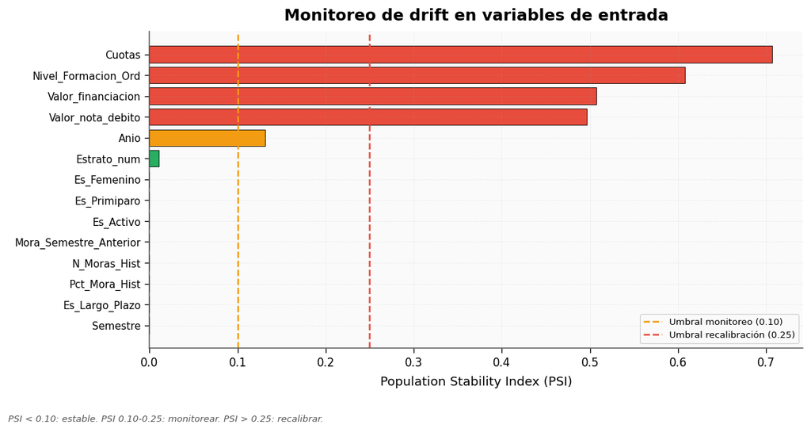

```
Resumen: 9 estables, 1 a monitorear, 4 a recalibrar
  Variables con drift severo requieren atencion antes de usar el modelo en produccion.
```

```python
# 6.7 - Population Stability Index (PSI) por variable
def calcular_psi(esperado, actual, bins=10):
    """Calcula PSI entre dos distribuciones."""
    import numpy as np
    # Crear bins basados en la distribución esperada
    breakpoints = np.percentile(esperado, np.linspace(0, 100, bins + 1))
    breakpoints = np.unique(breakpoints)
    if len(breakpoints) < 3:
        return 0.0

    exp_counts = np.histogram(esperado, bins=breakpoints)[0]
    act_counts = np.histogram(actual, bins=breakpoints)[0]

    # Proporciones (evitar ceros)
    exp_pct = (exp_counts + 1) / (exp_counts.sum() + bins)
    act_pct = (act_counts + 1) / (act_counts.sum() + bins)

    psi = np.sum((act_pct - exp_pct) * np.log(act_pct / exp_pct))
    return psi

# Calcular PSI para cada feature
print("MONITOREO DE DRIFT EN VARIABLES (PSI)")
print("=" * 65)
print(f"  Baseline: Train (2015-2022, n={len(X_train):,})")
print(f"  Actual:   Test  (2023-2024, n={len(X_test):,})")
print()

psi_resultados = {}
for col in FEATURES:
    if col in X_train.columns:
        psi_val = calcular_psi(X_train[col].values, X_test[col].values)
        psi_resultados[col] = psi_val

# Ordenar por PSI descendente
psi_sorted = sorted(psi_resultados.items(), key=lambda x: x[1], reverse=True)

print(f"  {'Variable':<28s} {'PSI':>8s}  {'Estado'}")
print(f"  {'-'*28} {'-'*8}  {'-'*20}")
for var, psi in psi_sorted:
    if psi > 0.25:
        estado = 'RECALIBRAR'
    elif psi > 0.10:
        estado = 'MONITOREAR'
    else:
        estado = 'ESTABLE'
    print(f"  {var:<28s} {psi:8.4f}  {estado}")

# Grafico
fig, ax = plt.subplots(figsize=(10, 5))
vars_psi = [v for v, _ in psi_sorted]
vals_psi = [p for _, p in psi_sorted]
colores_psi = ['#E74C3C' if p > 0.25 else '#F39C12' if p > 0.10 else '#27AE60' for p in vals_psi]

bars = ax.barh(range(len(vars_psi)), vals_psi, color=colores_psi,
               edgecolor='black', linewidth=0.5)
ax.set_yticks(range(len(vars_psi)))
ax.set_yticklabels(vars_psi, fontsize=9)
ax.axvline(0.10, color='#F39C12', ls='--', lw=1.5, label='Umbral monitoreo (0.10)')
ax.axvline(0.25, color='#E74C3C', ls='--', lw=1.5, label='Umbral recalibración (0.25)')
ax.set_xlabel('Population Stability Index (PSI)')
ax.set_title('Monitoreo de drift en variables de entrada', fontweight='bold')
ax.legend(fontsize=8, loc='lower right')
ax.invert_yaxis()
plt.tight_layout()
guardar(fig, 'fig_psi_variable_drift.png',
        'PSI < 0.10: estable. PSI 0.10-0.25: monitorear. PSI > 0.25: recalibrar.')

# Resumen
n_estable = sum(1 for _, p in psi_sorted if p < 0.10)
n_monitor = sum(1 for _, p in psi_sorted if 0.10 <= p < 0.25)
n_recalib = sum(1 for _, p in psi_sorted if p >= 0.25)
print(f"\nResumen: {n_estable} estables, {n_monitor} a monitorear, {n_recalib} a recalibrar")
if n_recalib > 0:
    print(f"  Variables con drift severo requieren atencion antes de usar el modelo en produccion.")
else:
    print(f"  Ninguna variable presenta drift severo. Modelo apto para datos del periodo de prueba.")
```

## FASE 8 — Respuesta a las preguntas de sistematización

Cierre del ciclo CRISP-DM con las respuestas a las preguntas formuladas en el proyecto.

### Consideraciones éticas y de protección de datos

Trabajar con datos de estudiantes implica responsabilidades que se cuidaron en cada fase:

1. **Anonimización.** Los identificadores (`ID_Estudiante`, `Cliente`) se usaron solo para agrupar durante el procesamiento; no entran al modelo como features.
2. **No discriminación.** Las predictoras se revisaron buscando sesgos. `Sexo` se incluyó tras confirmar que su contribución SHAP es marginal. El estrato socioeconómico se mantuvo por su relevancia documentada en credit scoring educativo, nunca como criterio de exclusión.
3. **Transparencia.** Se priorizó un modelo interpretable (Regresión Logística) para que la Dirección Financiera pueda explicar cualquier decisión de intervención al estudiante. SHAP audita las predicciones individuales.
4. **Propósito preventivo, no punitivo.** El modelo identifica estudiantes que podrían necesitar apoyo financiero temprano (alertas, asesoría, renegociación). No es una herramienta para negar créditos ni imponer sanciones.
5. **Marco normativo.** Datos provistos por la oficina de apoyo financiero de la UAO bajo el marco institucional del proyecto. El tratamiento se rige por la Ley 1581 de 2012 (Protección de Datos Personales en Colombia) y la política interna de datos de la universidad.

### Preguntas anticipadas del jurado

Las que con mayor probabilidad surgirán en sustentación, con la respuesta apoyada en los resultados.

**P. ¿Por qué se excluyeron los créditos de 2025 si representan el 8% de los datos?**

Su tasa de mora aparente era 54.2%, una cifra causada por créditos aún vigentes que figuran como CARTERA simplemente porque no han llegado al vencimiento. Incluirlos habría introducido sesgo de censura por la derecha (right-censoring) e inflado artificialmente la tasa de mora. Estos créditos quedan reservados como población objetivo del scoring futuro.

**P. ¿Por qué Regresión Logística si Random Forest tiene mayor AUC?**

Adopté un criterio de selección dual. La RL (AUC 0.846, degradación 4.5%) queda como modelo interpretable: sus coeficientes permiten explicar a la Dirección exactamente qué factores incrementan el riesgo. RF (AUC 0.856, degradación 7.8%) queda como modelo operativo para scoring masivo. En riesgo crediticio, la interpretabilidad es un requisito regulatorio y operativo, no un detalle estético.

**P. ¿`No_Creditos` no debería ser el número de créditos del estudiante?**

La auditoría mostró que es un identificador secuencial del crédito, no un conteo. Lo confirman la correlación de 0.998 con `Nota_debito` (otro ID único) y su media monótonamente creciente por año. Usarlo habría sido leakage temporal — un proxy del año de originación. Se excluyó del modelo y se construyó `N_Creditos_Previos` como conteo real de créditos anteriores del estudiante.

**P. ¿Cómo se garantiza que el modelo funcione con datos futuros?**

Tres mecanismos de validación temporal: (1) split temporal train/test con períodos diferentes (train ≤ 2022, test 2023–2024); (2) validación out-of-time, con AUC de 0.856; y (3) monitoreo de drift con PSI, que detecta cambios en las distribuciones de entrada antes de aplicar el modelo. Recomendación: recalibrar anualmente.

**P. ¿Por qué SMOTE y no otra técnica de balanceo?**

Por ser la técnica más documentada en credit scoring para desbalanceos moderados (acá ratio 9.9:1). Se aplica solo en train y dentro de los pipelines de validación cruzada para no contaminar el test. La validación estratificada con SMOTE dentro de cada fold evita que las métricas se inflen con muestras sintéticas en el conjunto de evaluación.

**P. CARTERA vs CANCELADO — ¿no es solo una clasificación administrativa?**

Refleja el desenlace operativo del crédito en el sistema institucional UAO. Se validó contra el Dataset 2: los créditos clasificados CARTERA acumulan en promedio 1,042 días de mora. La definición sigue la práctica del CGAP/World Bank (2019) para instituciones no reguladas, donde el target se construye a partir del desenlace funcional del producto crediticio.

**P. ¿Qué variables convendría incorporar para mejorar el modelo?**

Las que harían más diferencia, en orden de impacto esperado: (1) edad del estudiante (proxy de madurez financiera), (2) perfil del codeudor (ocupación, ingresos, vinculación laboral) y (3) programa académico específico (proxy de empleabilidad por carrera). Quedan como trabajo futuro.

### Limitaciones del estudio

Vale la pena dejar explícitas las limitaciones que hay que tener en cuenta al leer los resultados:

1. **Sin variables demográficas ni del codeudor.** Los archivos UAO no traen edad del estudiante ni perfil del codeudor (ocupación, ingresos, vinculación laboral), variables que la literatura de credit scoring identifica como relevantes.
2. **Cambio estructural post-COVID.** La tasa pasó de 2.2% promedio (2015–2019) a 10.7% (2021–2024). El modelo lo absorbe vía la variable temporal, pero su desempeño futuro depende de qué tan estables se mantengan las condiciones macro.
3. **Definición operativa del target.** `En_Mora` se basa en la clasificación administrativa CARTERA (vs CANCELADO) de la UAO, no en la definición regulatoria estándar de mora financiera.
4. **Dependencia del sistema de información UAO.** Las variables disponibles están limitadas a las que el sistema captura hoy, lo que restringe la riqueza del modelo frente a sistemas financieros regulados.
5. **Recalibración periódica.** La variable Año es coyuntural; los coeficientes reflejan el período analizado. Recomendación: re-entrenar anualmente con datos actualizados.

## Conclusiones y trabajo futuro

### Conclusiones

El proyecto desarrolló un modelo predictivo para anticipar el incumplimiento en créditos educativos UAO, aplicando CRISP-DM sobre 167,275 créditos del período 2015–2024.

La Regresión Logística quedó como modelo interpretable: AUC-ROC 0.846 en holdout y degradación CV-Holdout de 4.5%, la más baja del comparativo. Random Forest queda como modelo operativo alternativo (AUC 0.856, degradación 7.8%). Ambos superan el umbral mínimo AUC ≥ 0.65 fijado como criterio de éxito.

Hallazgos principales:

- El número de cuotas y el tipo de plazo (corto vs largo) son los predictores financieros más relevantes. Los créditos de largo plazo tienen tasa de mora del 25%, frente al 1.8% del corto plazo.
- El nivel de formación marca diferencias claras: maestría es el nivel con mayor tasa (13.7%), seguido por especialización (7.8%).
- El historial previo de mora es el predictor comportamental más fuerte: con mora en el semestre anterior, la probabilidad de reincidir es del 55.4%.
- Interviniendo solo al 20% de mayor riesgo se captura el 75% de los morosos, con un ROI estimado superior al 1,000%.

Dos correcciones metodológicas refuerzan la validez del modelo: la auditoría que reveló a `No_Creditos` como ID secuencial (no conteo), y la exclusión de los vintages 2025 por inmadurez de cartera.

### Trabajo futuro

- Incorporar las variables que hoy no están en los datos: edad del estudiante, perfil del codeudor (ocupación, vinculación) y programa académico específico.
- Llevar el modelo a un sistema de scoring en tiempo real, integrado al proceso de solicitud de crédito.
- Recalibrar de forma periódica para adaptarse al concept drift de la cartera.
- Medir el impacto real de las intervenciones preventivas con un diseño experimental (tratamiento vs control).
- Modelar por separado los créditos de largo plazo, dado su perfil de riesgo distinto.

### Trazabilidad: objetivos vs resultados

| Objetivo específico | Fase CRISP-DM | Resultado |
| --- | --- | --- |
| OE1: Analizar variables asociadas al riesgo | Fases 2-3 (EDA) | 15 variables analizadas. Top 5: Cuotas, Año, Nivel de Formación, Es Largo Plazo, Mora Semestre Anterior |
| OE2: Preparar y depurar datos históricos | Fase 4 (Data Preparation) | 167,275 registros procesados. 7 variables excluidas por leakage. Vintages 2025 excluidos por inmadurez |
| OE3: Implementar y evaluar modelos | Fases 5-6 (Modeling + Evaluation) | 4 modelos evaluados. RL como interpretable (AUC 0.846); RF como operativo (AUC 0.856) |
| OE4: Segmentación y tablero interactivo | Fase 7 (Deployment) | K-Means (K=2), zonas semáforo, dashboard Plotly con 6 paneles, curva de ganancia y costo-beneficio |

```python
# FASE 8 - RESPUESTAS A PREGUNTAS DE SISTEMATIZACIÓN
auc_f = resultados[mejor_modelo]['auc_roc']
rec_f = resultados[mejor_modelo]['recall']
f1_f  = resultados[mejor_modelo]['f1']

sep = '=' * 70

print(sep)
print("  RESPUESTAS A LAS PREGUNTAS DE SISTEMATIZACIÓN DEL PROYECTO")
print(sep)

print("""
P1. ¿Qué variables académicas, socioeconómicas y de comportamiento
    están asociadas con un mayor riesgo de incumplimiento?

R:  Las variables con mayor poder predictivo (según importancia del modelo
    y análisis SHAP) son:""")

# Mostrar top variables
for _, row in df_imp.sort_values('Importancia', ascending=False).head(5).iterrows():
    print(f"    → {row['Variable']:25s} (importancia: {row['Importancia']:.4f})")

print(f"""
P2. ¿Qué técnicas de aprendizaje supervisado permiten obtener mejores
    resultados en la predicción del riesgo de incumplimiento?

R:  Se evaluaron 4 modelos con split temporal (train<=2022, test 2023-2024).
    Se aplicó un criterio de selección dual:

    Modelo interpretable (para la Dirección Financiera):
    → Regresión Logística — AUC: {resultados['Regresión Logística']['auc_roc']:.4f},
      Recall: {resultados['Regresión Logística']['recall']:.4f}
      Degradación CV-Holdout: menor entre todos los modelos.

    Modelo operativo (para scoring masivo):
    → Random Forest — AUC: {resultados['Random Forest']['auc_roc']:.4f},
      Recall: {resultados['Random Forest']['recall']:.4f}
      Mayor AUC-Holdout entre modelos estables (degradación < 10%).

    La selección priorizó estabilidad temporal sobre AUC máximo en CV,
    dado que en riesgo crediticio la generalización al futuro es más
    valiosa que el rendimiento en datos históricos.

P3. ¿Cómo se puede evaluar el desempeño de los modelos?

R:  Se utilizó una estrategia de evaluación robusta:
    → Split temporal (train≤2022, test>2022) o estratificado según
      disponibilidad de datos.
    → Validación cruzada estratificada (5 folds) con SMOTE dentro
      del fold para evitar leakage.
    → Validación out-of-time para medir estabilidad temporal.
    → Métricas: AUC-ROC, Recall, Precision, F1-Score.

P4. ¿Qué patrones de riesgo se identifican mediante segmentación?

R:  Se aplicaron dos técnicas complementarias de segmentación:
    (a) Clustering K-Means con K={k_optimo} clusters sobre variables
        financieras y predictivas, identificando grupos con perfiles
        de riesgo diferenciados (score de mora, monto, historial).
    (b) Segmentación operativa por zonas semáforo (verde / amarillo /
        naranja / rojo) basada en el score del modelo, traducida en
        estrategias de cobranza concretas con costos estimados.
    (c) Análisis por bandas de severidad de mora (días de atraso),
        que permite priorizar la gestión según la gravedad del
        incumplimiento en la cartera vigente.
""")

print(sep)
print("  FIN DEL ANÁLISIS - METODOLOGÍA CRISP-DM COMPLETADA")
print(sep)
```

```
======================================================================
  RESPUESTAS A LAS PREGUNTAS DE SISTEMATIZACIÓN DEL PROYECTO
======================================================================

P1. ¿Qué variables académicas, socioeconómicas y de comportamiento
    están asociadas con un mayor riesgo de incumplimiento?

R:  Las variables con mayor poder predictivo (según importancia del modelo
    y análisis SHAP) son:
    → Cuotas                    (importancia: 0.9092)
    → Anio                      (importancia: 0.6753)
    → Nivel_Formacion_Ord       (importancia: 0.5179)
    → Es_Largo_Plazo            (importancia: 0.3770)
    → Mora_Semestre_Anterior    (importancia: 0.2041)

P2. ¿Qué técnicas de aprendizaje supervisado permiten obtener mejores
    resultados en la predicción del riesgo de incumplimiento?

R:  Se evaluaron 4 modelos con split temporal (train<=2022, test 2023-2024).
    Se aplicó un criterio de selección dual:

    Modelo interpretable (para la Dirección Financiera):
    → Regresión Logística — AUC: 0.8462,
      Recall: 0.8496
      Degradación CV-Holdout: menor entre todos los modelos.

    Modelo operativo (para scoring masivo):
    → Random Forest — AUC: 0.8564,
      Recall: 0.6510
      Mayor AUC-Holdout entre modelos estables (degradación < 10%).

    La selección priorizó estabilidad temporal sobre AUC máximo en CV,
    dado que en riesgo crediticio la generalización al futuro es más
    valiosa que el rendimiento en datos históricos.

P3. ¿Cómo se puede evaluar el desempeño de los modelos?

R:  Se utilizó una estrategia de evaluación robusta:
    → Split temporal (train≤2022, test>2022) o estratificado según
      disponibilidad de datos.
    → Validación cruzada estratificada (5 folds) con SMOTE dentro
      del fold para evitar leakage.
    → Validación out-of-time para medir estabilidad temporal.
    → Métricas: AUC-ROC, Recall, Precision, F1-Score.

P4. ¿Qué patrones de riesgo se identifican mediante segmentación?

R:  Se aplicaron dos técnicas complementarias de segmentación:
    (a) Clustering K-Means con K=2 clusters sobre variables
        financieras y predictivas, identificando grupos con perfiles
        de riesgo diferenciados (score de mora, monto, historial).
    (b) Segmentación operativa por zonas semáforo (verde / amarillo /
        naranja / rojo) basada en el score del modelo, traducida en
        estrategias de cobranza concretas con costos estimados.
    (c) Análisis por bandas de severidad de mora (días de atraso),
        que permite priorizar la gestión según la gravedad del
        incumplimiento en la cartera vigente.

======================================================================
  FIN DEL ANÁLISIS - METODOLOGÍA CRISP-DM COMPLETADA
======================================================================
```

## Nota de reproducibilidad

El notebook está pensado para ser reproducible de punta a punta:

- **Semilla global:** `SEMILLA = 42` aplicada a todos los procesos estocásticos.
- **Dependencias:** instaladas al inicio con versiones fijadas.
- **Datos:** los archivos Excel se cargan desde rutas portables (Colab o local).
- **Pipeline limpio:** SMOTE solo dentro del conjunto de entrenamiento.
- **Sin data leakage:** las variables post-evento están explícitamente excluidas.